# Inequality in Education Around the World

Olivia Jiang

November 4, 2026

### Introduction

This project examines the differences in educational development around the world. The quality of education among a country’s population is an important indicator of the wellbeing and future advancement of a country, yet it varies significantly across different places and groups of people.

What I really love about statistics is its ability to quantitatively reveal how unequal things are across different groups of people, so that we know who might need more support.

I used data from the United Nations’ Human Development Reports by the UN Development Program on the educational attributes of countries’ adults 25 and older, specifically 34 years (1990 to 2023) of it from the [UNDP’s open database](https://hdr.undp.org/data-center/documentation-and-downloads). Note that the variables that I’m interested in were missing data past 2023 so the past couple of years (2024 and 2025) aren’t included in my analysis.

I’ll focus on the following measures of educational development: the average amount of formal education attained by men and women (individually) within a country, the percentage of men and women (individually) with at least secondary education within a country, and the average amount of education attained by adults 25+ within a country. Note that secondary education, under the [UN’s International Standard Classification of Education (ISCED)](https://www.uis.unesco.org/en/methods-and-tools/isced), is defined as an intermediate phase of education spanning ages 11 to 18.

### Gender inequality

To view educational inequalities in terms of gender, I’m using two metrics: (1) the average amount of formal education attained by each gender, and (2) the percentage of adults in each gender who have at least some level of secondary education.

Here are graphs of these metrics by gender worldwide:

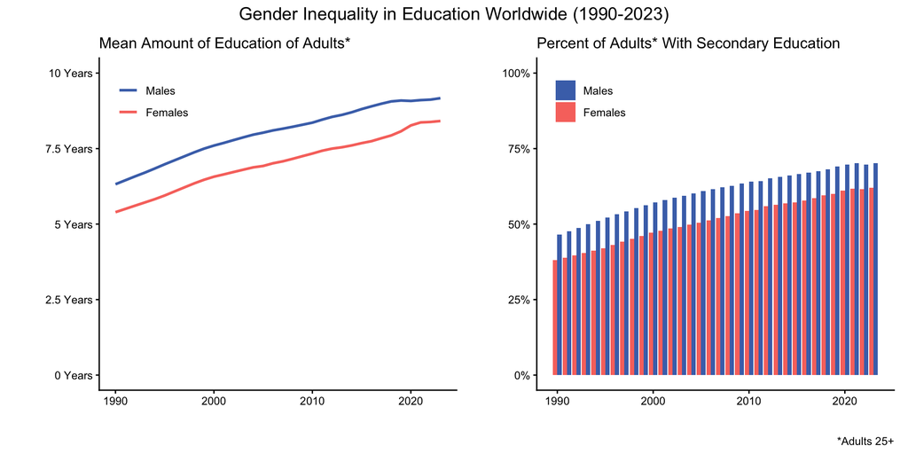

For both metrics, the amount for females has never been more than for males: although they’ve been increasing at similar speeds — the lines in both charts are nearly parallel — there has always been a gap of around one year or 10 percentage points. However, the gap has been shrinking for the past few years. In 2020, the magnitude of the gap dropped to a new low of 0.8 years, to 0.7 years in 2021 and 2022, and 0.8 years in 2023. Similarly, the percentage of males vs. females with secondary education worldwide shrunk to 8 percentage points in 2023.

So where specifically in the world do the highest gender gaps consistently occur?

Countries With Consistently High Gender Gaps* (1990-2023)

| Continent | Country | # of Times in Highest 10 |
| --- | --- | --- |
| Africa | Democratic Republic of the Congo | 34 |
| Africa | Liberia | 34 |
| Africa | Togo | 30 |
| Africa | Ghana | 22 |
| Asia | Pakistan | 18 |
| Asia | Nepal | 16 |
| Africa | Congo | 11 |
| Asia | Saudi Arabia | 11 |
| Asia | Yemen | 10 |
| Africa | Angola | 9 |
| Asia | India | 7 |
| Africa | Guinea-Bissau | 4 |
| Africa | Nigeria | 4 |
| Asia | Iraq | 2 |
| Africa | Cameroon | 1 |

*Ranked in terms of both the average amount of education and the percentage with secondary education (in each gender for adults 25+) simultaneously.

There are 15 countries in this table (out of 195 total countries in the data), of which the Democratic Republic of the Congo and Liberia have been there in 34 of the 34 years.

Here’s a likewise breakdown by continent:

Continents With Consistently High Gender Gaps* (1990-2023)

| Continent | # of Times in Highest 10 | % of Countries |
| --- | --- | --- |
| Africa | 149 | 69.95 |
| Asia | 64 | 30.05 |

*Ranked in terms of both the average amount of education and the percentage with secondary education (in each gender for adults 25+) simultaneously.

The only continents in this table are Africa and Asia. The rightmost column shows the percent share of countries that belong to that continent.

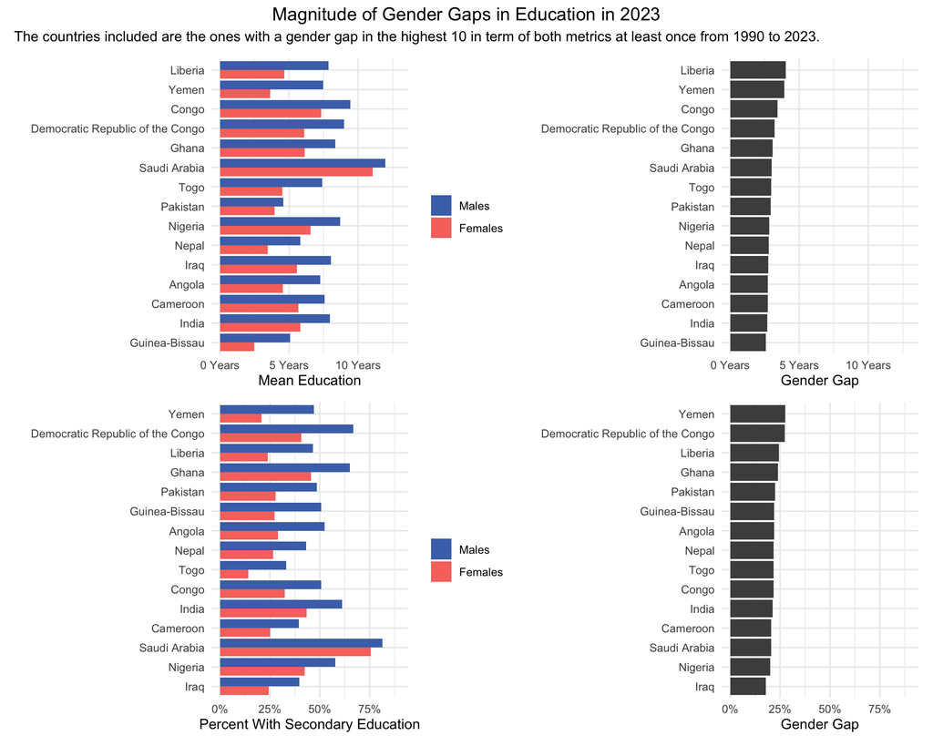

### Geographic inequality

Next, I view the geographic variation in terms of the average amount of education for adults to contrast individual continents and countries.

I created a graph of each continent’s average amount of education:

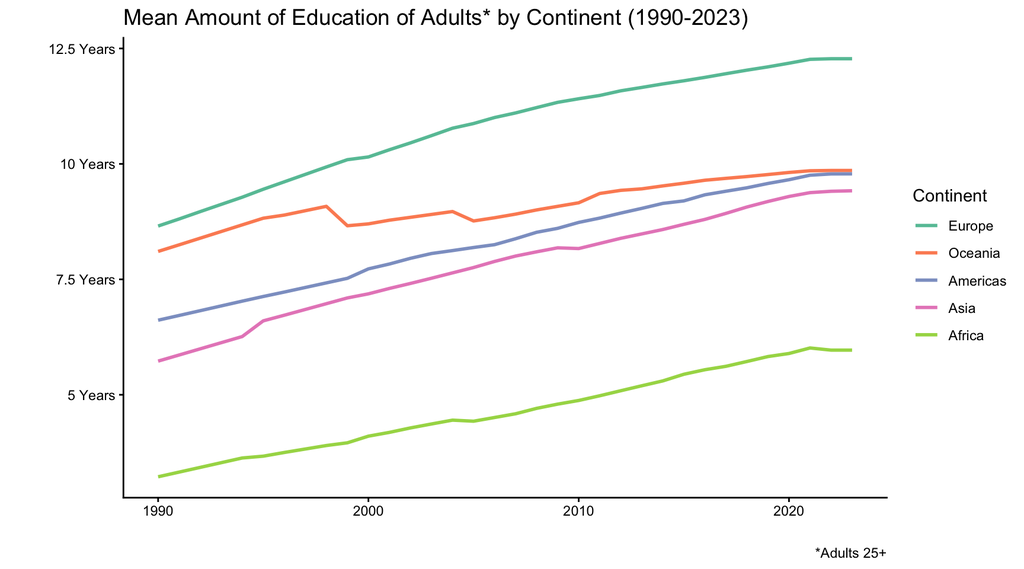

To further get a sense of the widest differences globally, here are the highest and lowest-ranked countries from 1990 to 2023:

Biggest Gaps in Education by Country (1990-2023)

| Year Range | Lowest Country | Highest Country | Average Gap (Years) |
| --- | --- | --- | --- |
| 1990 - 1997 | Yemen | United States | 12.5 |
| 1998 - 2000 | Niger | United States | 11.9 |
| 2001 - 2002 | Niger | New Zealand | 11.9 |
| 2003 | Niger | Germany | 12.2 |
| 2004 | Mali | Germany | 12.5 |
| 2005 - 2014 | Burkina Faso | Germany | 12.7 |
| 2015 - 2023 | Niger | Germany | 12.8 |

The differences range from 11.8-12.9 years and have a small standard deviation of 0.3 years, again because the rate of growth has been similar worldwide. Niger and Germany appear with the highest frequency, each appearing 4 times. The US appears twice, and Yemen, Mali, Burkina Faso, and New Zealand appear once, which indeed reflects the state of the continental rankings.

Once again, I want to know which countries have the most consistently low averages from the full range of the data, so here are the countries that have been in the bottom 10 at least once (in terms of the average amount of education of its population over 25 years):

Countries With Consistently Low Education Rates (1990-2023)

| Continent | Country | # of Times in Bottom 10 |
| --- | --- | --- |
| Africa | Guinea | 34 |
| Africa | Mali | 34 |
| Africa | Niger | 34 |
| Asia | Afghanistan | 34 |
| Africa | Senegal | 29 |
| Africa | Chad | 24 |
| Africa | Ethiopia | 24 |
| Africa | Burundi | 23 |
| Africa | Benin | 20 |
| Africa | Burkina Faso | 19 |
| Africa | Mozambique | 19 |
| Asia | Yemen | 16 |
| Africa | Djibouti | 14 |
| Africa | Gambia | 5 |
| Africa | Sudan | 5 |
| Asia | Bhutan | 4 |
| Africa | Somalia | 2 |

There are 17 countries that have been in the bottom 10 at least once, of which 4 countries (Afghanistan, Guinea, Mali, and Niger) have been there in every year of the 34.

Here’s a similar breakdown by continent:

Continents With Consistently Low Education Rates (1990-2023)

| Continent | # of Times in Bottom 10 | % of Countries |
| --- | --- | --- |
| Africa | 286 | 84.12 |
| Asia | 54 | 15.88 |

Now to focus on 2023 again, I found the countries in the lowest 10 in 2023:

Countries With the Lowest Average Education in 2023

| Continent | Country | Mean Amount of Education (Years) | Distance Below World Average (Years) |
| --- | --- | --- | --- |
| Africa | Niger | 1.4 | 7.4 |
| Africa | Mali | 1.6 | 7.1 |
| Africa | Somalia | 1.9 | 6.9 |
| Africa | Burkina Faso | 2.3 | 6.5 |
| Africa | Chad | 2.3 | 6.4 |
| Africa | Ethiopia | 2.4 | 6.4 |
| Africa | Guinea | 2.5 | 6.3 |
| Asia | Afghanistan | 2.5 | 6.3 |
| Africa | Senegal | 2.9 | 5.8 |
| Africa | Benin | 3.2 | 5.6 |

And the highest 10:

Countries With the Highest Average Education in 2023

| Continent | Country | Mean Amount of Education (Years) | Distance Above World Average (Years) |
| --- | --- | --- | --- |
| Europe | Germany | 14.3 | 5.5 |
| Europe | Switzerland | 13.9 | 5.2 |
| Americas | United States | 13.9 | 5.1 |
| Europe | Iceland | 13.9 | 5.1 |
| Americas | Canada | 13.9 | 5.1 |
| Europe | Lithuania | 13.6 | 4.8 |
| Europe | Estonia | 13.6 | 4.8 |
| Asia | Israel | 13.5 | 4.8 |
| Europe | United Kingdom | 13.5 | 4.7 |
| Europe | Latvia | 13.4 | 4.6 |

I distilled this information into a graph:

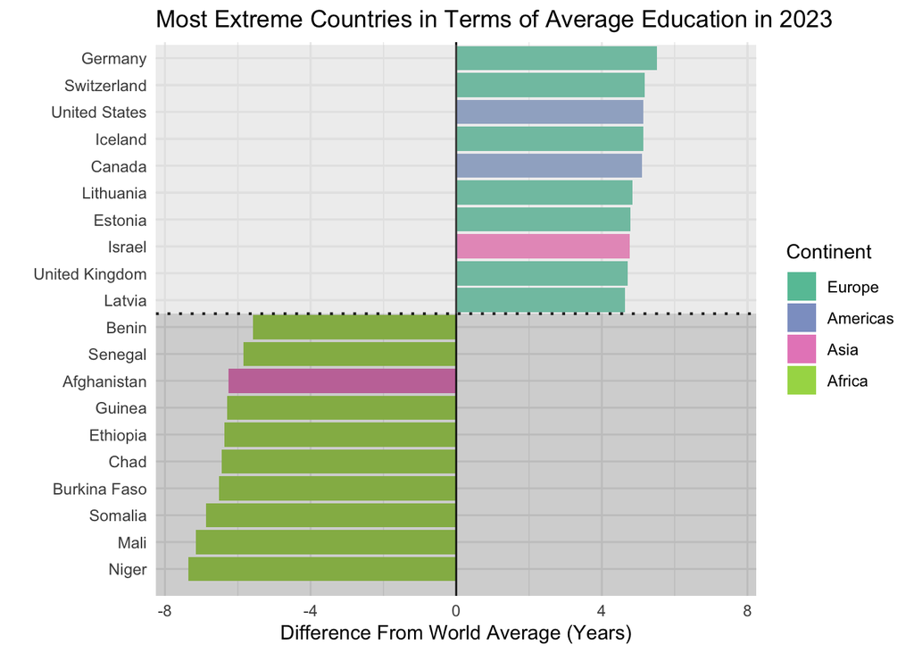

Africa appears 9 times and Asia appears once in the bottom 10. Europe appears 7 times, Americas appears twice, and Asia appears once in the top 10. (The rest of the countries are obviously just between these two extremes.) Clearly, the asymmetry between the two extremes was still quite striking in 2023 despite Africa’s steady growth through the years which nearly doubled its mean education amount from 3.2 years in 1990 to 6 years in 2023.

### Summary

Lastly, I want to mention that this study isn’t perfect. For example, regarding the data, there was likely undersampling, which compromises how representative my results are. In addition, education is only one take on a country’s level of development, and I could delve deeper into why these educational disparities exist and whether there are meaningful relationships between gender, geographic, and other types of inequality. But again, what I love about statistics is its ability to quantitatively demonstrate real inequalities — in order to help real people — and hopefully this study shows one way to do that.